# Permutation tests

Peter Ralph

Advanced Biological Statistics

# Permutation tests

```
##
##  Welch Two Sample t-test
##
## data:  airbnb$price[airbnb$instant_bookable] and airbnb$price[!airbnb$instant_bookable]
## t = 3.6482, df = 5039.8, p-value = 0.0002667
## alternative hypothesis: true difference in means is not equal to 0
## 95 percent confidence interval:
##   4.475555 14.872518
## sample estimates:
## mean of x mean of y
##  124.6409  114.9668
```

**But,** the $t$ test relies on *Normality* (a little). Is the distribution of AirBnB prices too “weird”? How can we be sure?

Methods:

1. Remove the big values and try again.
2. Use a nonparametric test.

## The permutation test

*Observation:* **If** there was no meaningful difference in prices between “instant bookable” and not, **then randomly shuffling that label** won’t change anything.

Strategy:

1. Shuffle the `instant_bookable` column.
2. Compute the difference in means.
3. Repeat, many times.
4. Compare: the $p$-value is the proportion of “shuffled” values more extreme than observed.

*Why* is this a $p$-value? For what hypothesis?

## Shuffle once

```r
fake_is_instant <- sample(airbnb$instant_bookable)
(mean(airbnb$price[fake_is_instant], na.rm=TRUE) -
                mean(airbnb$price[!fake_is_instant], na.rm=TRUE))
```

```
## [1] 2.837541
```

## Many times

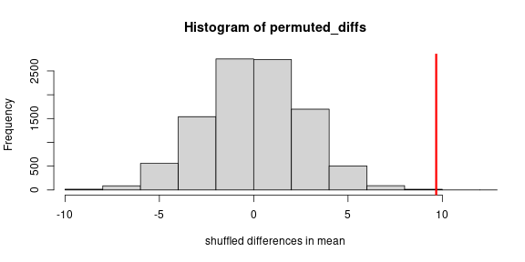

```r
real_diff <- (mean(airbnb$price[airbnb$instant_bookable], na.rm=TRUE)
               - mean(airbnb$price[!airbnb$instant_bookable], na.rm=TRUE))
permuted_diffs <- replicate(10000, {
        fake_is_instant <- sample(airbnb$instant_bookable)
        (mean(airbnb$price[fake_is_instant], na.rm=TRUE)
             - mean(airbnb$price[!fake_is_instant], na.rm=TRUE))
   } )
hist(permuted_diffs, xlab="shuffled differences in mean", xlim=range(c(permuted_diffs, real_diff)))
abline(v=real_diff, col='red', lwd=3)
```

## How surprising was the real value?

```r
mean(abs(permuted_diffs) > abs(real_diff))
```

```
## [1] 3e-04
```

> The difference in price between instant bookable and not instant bookable is highly statistically significant ($p \approx 0.0003$, permutation test).

## Our turn

Here’s a *nonparametric* method to see if omnivores tend to be bigger than herbivores in the [PanTHERIA data](https://github.com/UO-Biostats/UO_ABS/tree/master/CLASS_MATERIALS/Datasets/PanTHERIA):

1. Find pairs of species in the same family for which one is a omnivore and the other an herbivore.
2. Compute within each pair **(some statistic)** comparing omnivore to herbivore size, and average these (the test statistic).
3. *Randomly reassign* “trophic level” within families many times, recomputing this statistic.
4. The $p$-value is the proportion of shuffled statistics greater than the observed statistic.

## In class

```r
source("../Datasets/PanTHERIA/read_pantheria.R")
pantheria <- read_pantheria("../Datasets/PanTHERIA")
```

First, let’s subset down to only the herbivores and omnivores, with non-missing data.

```r
pantheria <- subset(pantheria,
                    TrophicLevel %in% c("herbivore", "omnivore")
                    &
                    !is.na(AdultBodyMass_g)
) |> droplevels()
```

We still have 1430 species remaining.

## For each family, pick a pair of species:

```r
ratios <- rep(NA, nlevels(pantheria$Family))
names(ratios) <- levels(pantheria$Family)
for (fam in levels(pantheria$Family)) {
    this_fam <- subset(pantheria, Family == fam)
    omnis <- which(this_fam$TrophicLevel == "omnivore")
    herbs <- which(this_fam$TrophicLevel == "herbivore")
    if (length(omnis) > 0 && length(herbs) > 0) {
        herb <- herbs[sample.int(length(herbs), 1)]
        omni <- omnis[sample.int(length(omnis), 1)]
        out <- this_fam$AdultBodyMass_g[herb] / this_fam$AdultBodyMass_g[omni]
    } else {
        out <- NA
    }
    ratios[fam] <- out
}
```

## Do it again, after shuffling

```r
shuffled_mean_ratios <- replicate(100, {
    shuffled_ratios <- rep(NA, nlevels(pantheria$Family))
    names(ratios) <- levels(pantheria$Family)
    for (fam in levels(pantheria$Family)) {
        this_fam <- subset(pantheria, Family == fam)
        # shuffle up trophic level column
        this_fam$TrophicLevel <- sample(this_fam$TrophicLevel)
        omnis <- which(this_fam$TrophicLevel == "omnivore")
        herbs <- which(this_fam$TrophicLevel == "herbivore")
        if (length(omnis) > 0 && length(herbs) > 0) {
            herb <- herbs[sample.int(length(herbs), 1)]
            omni <- omnis[sample.int(length(omnis), 1)]
            out <- this_fam$AdultBodyMass_g[herb] / this_fam$AdultBodyMass_g[omni]
        } else {
            out <- NA
        }
        shuffled_ratios[fam] <- out
    }
    mean(shuffled_ratios, na.rm=TRUE)
})
```

## Look at the results

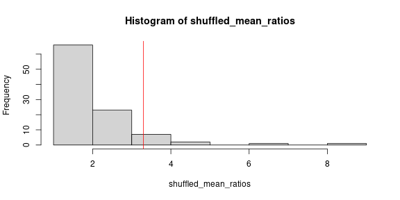

```r
observed_mean_ratio <- mean(ratios, na.rm=TRUE)
p_val <- mean(shuffled_mean_ratios > observed_mean_ratio)
hist(shuffled_mean_ratios)
abline(v=observed_mean_ratio, col='red')
```

## Conclusion

On average the herbivore of the pair was 3.2959199 times bigger than the omnivore; a mean ratio this big occurred 0.08 of the time in the permuted datasets. So, this is not strong evidence that herbivores tend to be bigger than omnivores (p = 0.08, permutation test).

*However*, we only did *one* random draw of the pairs to get the observed values.

## Lots of draws of pairs, unshuffled

```r
observed_mean_ratio_vector <- replicate(100, {
    ratios <- rep(NA, nlevels(pantheria$Family))
    names(ratios) <- levels(pantheria$Family)
    for (fam in levels(pantheria$Family)) {
        this_fam <- subset(pantheria, Family == fam)
        omnis <- which(this_fam$TrophicLevel == "omnivore")
        herbs <- which(this_fam$TrophicLevel == "herbivore")
        if (length(omnis) > 0 && length(herbs) > 0) {
            herb <- herbs[sample.int(length(herbs), 1)]
            omni <- omnis[sample.int(length(omnis), 1)]
            out <- this_fam$AdultBodyMass_g[herb] / this_fam$AdultBodyMass_g[omni]
        } else {
            out <- NA
        }
        ratios[fam] <- out
    }
    mean(ratios, na.rm=TRUE)
})
```

## Look at results again

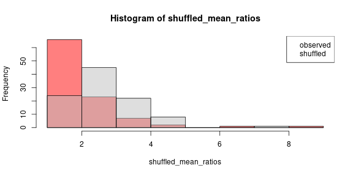

```r
xh <- hist(c(observed_mean_ratio_vector, shuffled_mean_ratios), plot=FALSE)
hist(shuffled_mean_ratios, breaks=xh$breaks,  col=adjustcolor('red', 0.5))
hist(observed_mean_ratio_vector, breaks=xh$breaks, add=TRUE, col=adjustcolor("grey", 0.5))
legend("topright", col=c("white", "red"),
       legend=c("observed", "shuffled")
)
```

Conclusion? Well, a t-test says:

```r
t.test(observed_mean_ratio_vector, shuffled_mean_ratios)
```

```
##
##  Welch Two Sample t-test
##
## data:  observed_mean_ratio_vector and shuffled_mean_ratios
## t = 4.4179, df = 194.6, p-value = 1.653e-05
## alternative hypothesis: true difference in means is not equal to 0
## 95 percent confidence interval:
##  0.3398443 0.8879671
## sample estimates:
## mean of x mean of y
##  2.649445  2.035539
```

… but we need to think about this more.